# Lab Test of Antenna S11

To cement the final iteration of the feed, which includes the dipole antenna and balun board, we constructed an impromptu mount in the lab and used the CMT R60 Vector Network Analyzer (hardware and software described in a previous memo) to test the S11 of the feed at the single-ended port of the balun. The OSL measurements and S-parameters of the cable-VNA system are presented here as well as the **calibrated** S11 of the feed itself.

### Note: The cmt_vna package on the EIGSEP GitHub is a dependency of this notebook.

```python
import numpy as np
import matplotlib.pyplot as plt
from cmt_vna import calkit as cal
%matplotlib widget

plt.rcParams.update({
    'legend.fontsize': 16,
    'axes.labelsize': 15,
    'font.family': 'serif',
    'xtick.labelsize': 13,
    'ytick.labelsize': 13,
    'axes.titlesize': 16
})
```

```python
data = np.load('../../antenna_s11_memo_materials/data/20250604_170642_vna_data.npz')
osl, gamma, freqs = data.values()
```

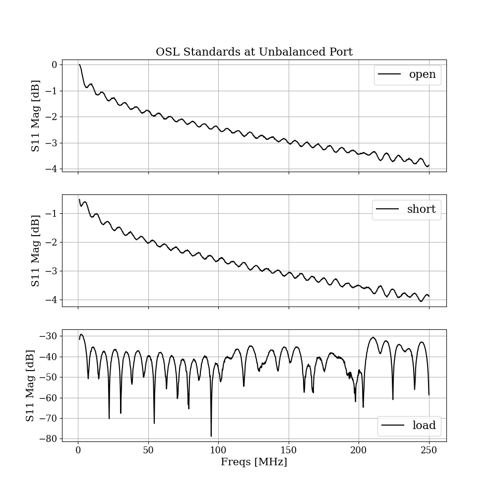

```python
fig, ax = plt.subplots(3,1,figsize=(10,10), sharex = True)

ax[0].set_title('OSL Standards at Unbalanced Port')

ax[0].plot(freqs/1e6, 20*np.log10(np.abs(osl[0])), color='black', label='open')
ax[0].grid()
ax[0].set_ylabel('S11 Mag [dB]')
ax[0].legend()

ax[1].plot(freqs/1e6, 20*np.log10(np.abs(osl[1])), color='black', label='short')
ax[1].grid()
ax[1].set_ylabel('S11 Mag [dB]')
ax[1].legend()

ax[2].plot(freqs/1e6, 20*np.log10(np.abs(osl[2])), color='black', label='load')
ax[2].grid()
ax[2].set_ylabel('S11 Mag [dB]')
ax[2].legend()
ax[2].set_xlabel('Freqs [MHz]')

plt.show()
```

Open and short should both be near zero, as they should have full reflection - the only difference between the two would be the phase - any variation from that would be attributed to the S-parameters of the system. The load measurement should be very, very low as there should be total absorption.

```python
#extracting S-parameters
kit = cal.S911T(freq_Hz = freqs)
sparams = kit.sparams(stds_meas = osl)
sparams_dict = {'vna': sparams}
```

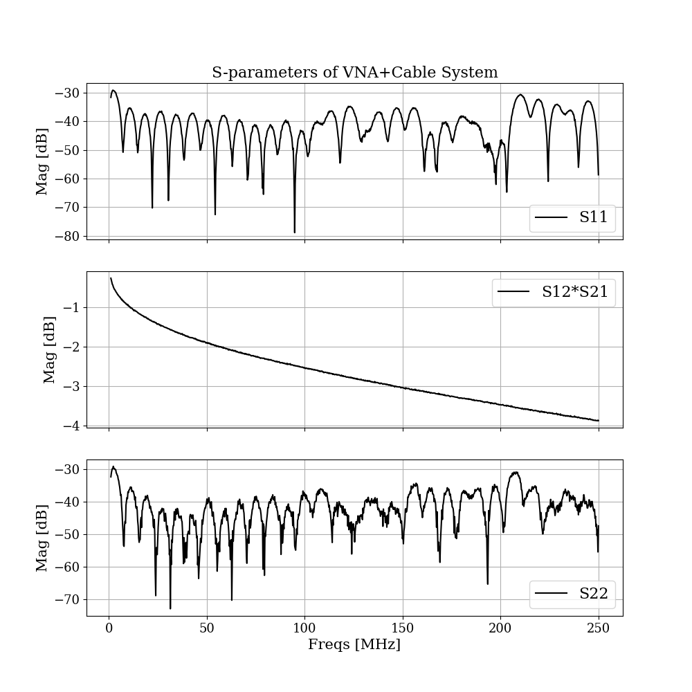

```python
fig, ax = plt.subplots(3,1,figsize=(10,10), sharex = True)

ax[0].set_title('S-parameters of VNA+Cable System')

ax[0].plot(freqs/1e6, 20*np.log10(np.abs(sparams[0])), color='black', label='S11')
ax[0].grid()
ax[0].set_ylabel('Mag [dB]')
ax[0].legend()

ax[1].plot(freqs/1e6, 20*np.log10(np.abs(sparams[1])), color='black', label='S12*S21')
ax[1].grid()
ax[1].set_ylabel('Mag [dB]')
ax[1].legend()

ax[2].plot(freqs/1e6, 20*np.log10(np.abs(sparams[2])), color='black', label='S22')
ax[2].grid()
ax[2].set_ylabel('Mag [dB]')
ax[2].legend()
ax[2].set_xlabel('Freqs [MHz]')

plt.show()
```

S11 and S22 should both be very low for a functioning system as it means that there is little reflection at either port. The through-parameters, S12 and S21 are returned as a product because of the nature of our S-parameter extraction method, to be detailed in a future memo. That product should be close to 0dB as the system should be letting everything through.

```python
#Calibrating the antenna measurement
gamma_cal = cal.calibrate(np.array([gamma]), sparams_dict)
```

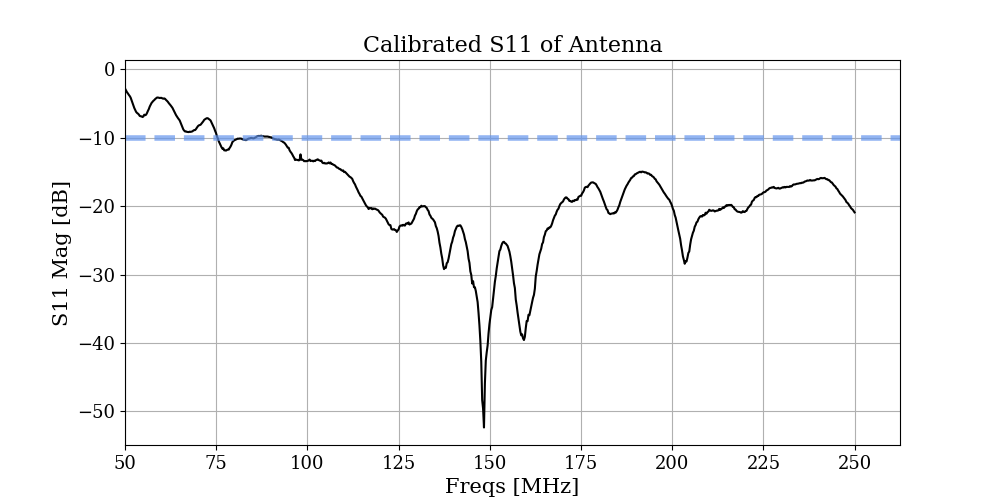

```python
plt.figure(figsize=(10,5))
plt.plot(freqs/1e6, 20*np.log10(np.abs(gamma_cal[0])), color='black')
plt.grid()
plt.title('Calibrated S11 of Antenna')
plt.xlabel('Freqs [MHz]')
plt.ylabel('S11 Mag [dB]')
plt.xlim(50)
plt.axhline(-10, linestyle='--', color='cornflowerblue', linewidth=4, alpha = 0.7)
plt.show()
```

```python
#calculating the distance that corresponds to the frequency ripples
t = 1/12.5e6 #s
c = 3e8 / 3 #m/s, with a factor of a third to account for speed of light through cable
d = c * t #distance in meters
print(f'Ripples correspond to approximately {d} meters.')
```

```
Ripples correspond to approximately 8.0 meters.
```

### Notable Features:

1. Past 75MHz, the S11 mostly stays below -10dB (indicated by the blue dashed line), which corresponds to getting a tenth of the power back that we sent in. This threshold is often used as a first test for a good S11.
2. There are some ripples on the order of 12.5MHz, which corresponds to about 8 meters. This is around the length of our cable.
3. It follows the same general trend as our simulation, including a large dip that gets past -50dB.

# Pic from post-measurement!

### Featuring Richard Saeed

[figure not shown]